# 03_preprocessamento.html

2025-04-29

## 🛠️ Pré-processamento

Nesta etapa, vamos realizar um pré-processamento mais refinado dos dados, que inclui: visualização espacial dos pontos para identificar padrões geográficos e possíveis inconsistências de localização; Filtragem de Linhas e Variáveis e Seleção de observações e atributos relevantes para as próximas etapas da análise; Detecção de Inconsistências: Identificação de valores extremos ou incoerentes que podem comprometer a qualidade das análises futuras.

### 📄 Carregando dados de emissões

```r
emissions_sources <- readr::read_rds("../data/emissions_sources.rds")
```

### 🔎 Validação dos dados (ano = 2021)

Após o tratamento, os dados foram analisados e comparados com as informações originais do site [Climate TRACE](https://climatetrace.org/), com o objetivo de verificar a consistência e a qualidade do processamento.

Ao buscar o município de **“Jaboticabal”** na plataforma, são apresentadas várias categorias de dados, referentes às emissões de gases de efeito estufa em diferentes níveis geográficos e fontes.

[figure not shown]

As principais categorias encontradas são:

- **City** - `Urban Area`, BR: Refere-se à área urbana da cidade em questão, no caso, Jaboticabal e apresenta dados de emissões provenientes das atividades dentro dessa zona, como transporte, indústria e outros fatores urbanos.

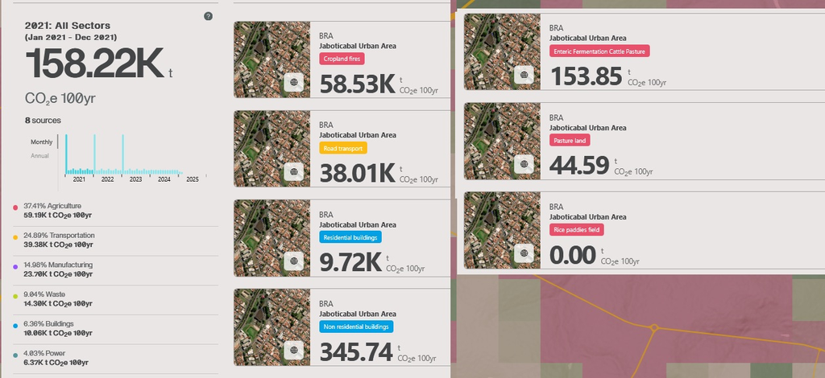

```r
emissions_sources |>
    dplyr::filter(
    stringr::str_detect(source_name, "Jaboticabal") | muni == "Jaboticabal",
    year == 2021,
    source_type == "Urban Area",
    # !subsector %in% c("forest-land-clearing",
    #                  "forest-land-degradation",
    #                  "forest-land-fires",
    #                  "removals",
    #                  "shrubgrass-fires",
    #                  "wetland-fires"),
    # sector != "forestry-and-land-use"
    ) |>
  dplyr::summarise(
    emissions_quantity_sum = sum(emissions_quantity, na.rm = TRUE)
  ) |>
  dplyr::ungroup() |>
  dplyr::mutate(
   emissions_quantity_cumsum = cumsum(emissions_quantity_sum)
  )
```

```
## # A tibble: 1 × 2
##   emissions_quantity_sum emissions_quantity_cumsum
##                    <dbl>                     <dbl>
## 1                106788.                   106788.
```

```r
emissions_sources |>
    dplyr::filter(
    stringr::str_detect(source_name, "Jaboticabal") | muni == "Jaboticabal",
    year == 2021,
    source_type == "Municipality",
    # !subsector %in% c("forest-land-clearing",
    #                  "forest-land-degradation",
    #                  "forest-land-fires",
    #                  "removals",
    #                  "shrubgrass-fires",
    #                  "wetland-fires"),
    # sector != "forestry-and-land-use"
    ) |>
  dplyr::summarise(
    emissions_quantity_sum = sum(emissions_quantity, na.rm = TRUE)
  ) |>
  dplyr::ungroup() |>
  dplyr::mutate(
   emissions_quantity_cumsum = cumsum(emissions_quantity_sum)
  )
```

```
## # A tibble: 1 × 2
##   emissions_quantity_sum emissions_quantity_cumsum
##                    <dbl>                     <dbl>
## 1               1107669.                  1107669.
```

- **Asset**: Refere-se a fontes específicas de emissões dentro da cidade ou município, como fábricas, usinas de energia ou instalações industriais. Cada “asset” tem dados específicos sobre suas emissões, permitindo uma análise mais detalhada.

```r
emissions_sources |>
    dplyr::filter(
    stringr::str_detect(source_name, "Jaboticabal") | muni == "Jaboticabal",
    year == 2021,
    source_type != "Municipality",
    source_type != "Urban Area",
    # !subsector %in% c("forest-land-clearing",
    #                  "forest-land-degradation",
    #                  "forest-land-fires",
    #                  "removals",
    #                  "shrubgrass-fires",
    #                  "wetland-fires"),
    # sector != "forestry-and-land-use"
    ) |>
  dplyr::group_by(source_name) |>
  dplyr::summarise(
    emissions_quantity_sum = sum(emissions_quantity, na.rm = TRUE)
  ) |>
  dplyr::ungroup() |>
  dplyr::mutate(
   emissions_quantity_cumsum = cumsum(emissions_quantity_sum)
  )
```

```
## # A tibble: 2 × 3
##   source_name                emissions_quantity_sum emissions_quantity_cumsum
##   <chr>                                       <dbl>                     <dbl>
## 1 ETE JABOTICABAL   SP                        6193.                     6193.
## 2 Santa Adélia power station                     0                      6193.
```

```r
emissions_sources |>
    dplyr::filter(stringr::str_detect(source_name, "Urban Area")) |> View()
```

### ⏳ Filtrando os dados para `forestry-and-land-use` e selecionando variáveis para a análise.

```r
emissions_sources_forestry <- emissions_sources |>
   dplyr::filter(
     gas == "co2e_100yr",
     sector == "forestry-and-land-use"
   ) |>
   dplyr::mutate(
     source_name = stringr::str_to_title(source_name)
   ) |>
  dplyr::select(
    -c(source_id,iso3_country,created_date,modified_date,lat_lon,directory,native_source_id,
       start_time,end_time,source_type,reporting_entity,sector_id,reporting_entity,geometry_ref)) |>
  dplyr::relocate(year,month,lon,lat,source_name,muni,state,region)
```

### 📈📊

Usa a função `vis_miss()` do pacote `{visdat}` para visualizar graficamente os dados faltantes (NAs).

Ele gera um gráfico de calor onde:

```
As células preenchidas mostram dados presentes.

As células em branco ou coloridas indicam dados ausentes.
```

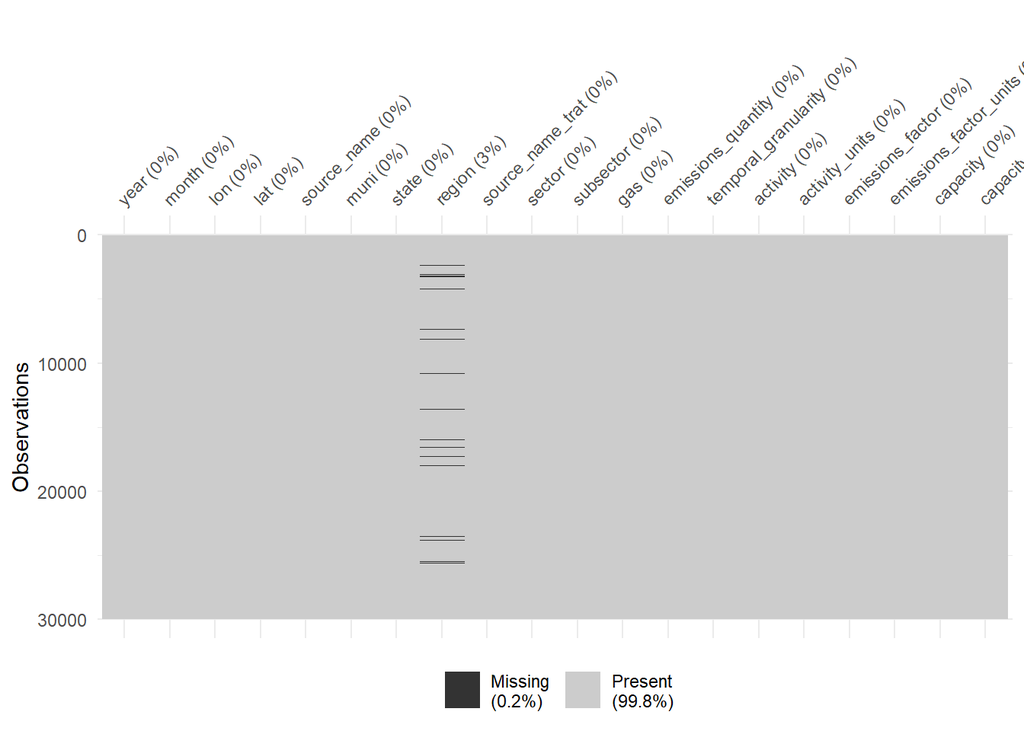

```r
emissions_sources_forestry[1:20] |>
  dplyr::sample_n(3e4) |>
  visdat::vis_miss()
```

### 🗺️ Plotando espacialmente os ponto

Nesta etapa, vamos representar os dados no espaço geográfico, gerando mapas que permitem visualizar a distribuição dos pontos de interesse. A plotagem espacial é fundamental para identificar padrões, áreas de maior concentração e possíveis anomalias nos dados.

Vamos carregar os polígonos de interesse

```r
country_br <- geobr::read_country(showProgress = FALSE)
conservation <- geobr::read_conservation_units(showProgress = FALSE)
indigenous <- geobr::read_indigenous_land(showProgress = FALSE)
```

Criando o mapa com sobreposição

Terras Indígenas reconhecidas

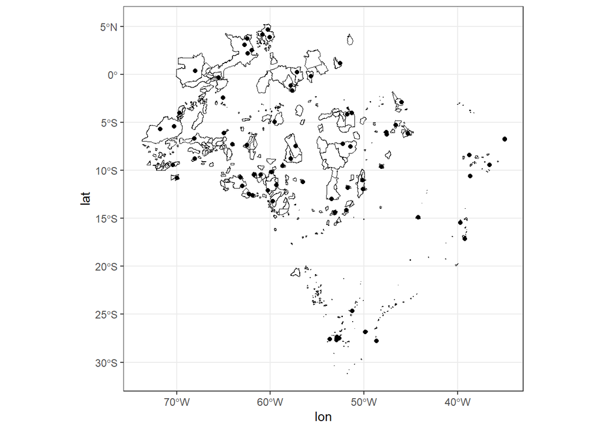

```r
indigenous    |>
  ggplot2::ggplot() +
  ggplot2::geom_sf(fill="white", color="black",
          size=.15, show.legend = FALSE) +
  ggplot2::geom_point(
    data = emissions_sources_forestry  |>
      dplyr::filter(
        year == 2021,
        indigenous != "Other"),
     ggplot2::aes(lon,lat)) +
  ggplot2::theme_bw()
```

Áreas de conservação

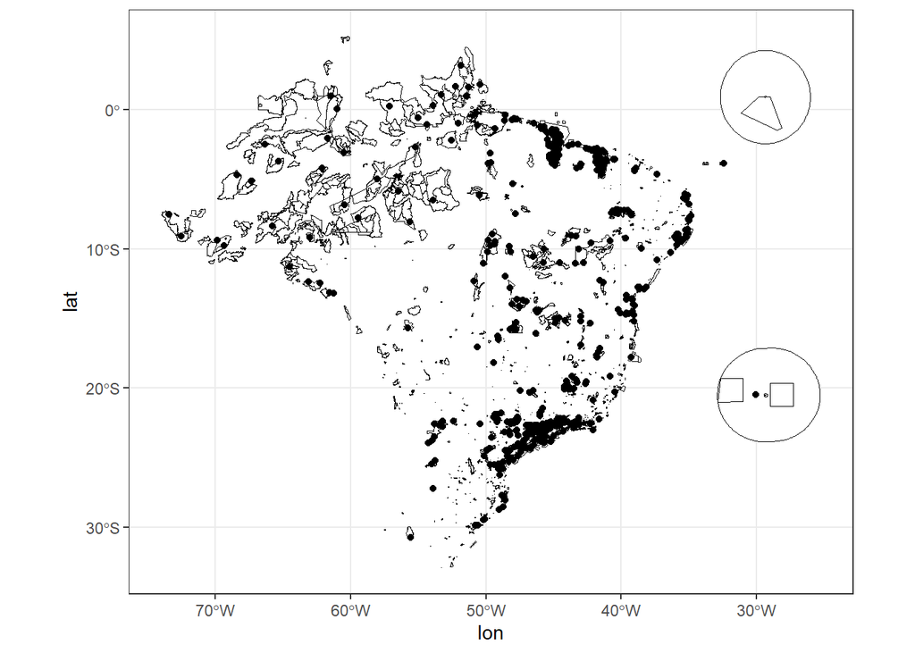

```r
conservation    |>
  ggplot2::ggplot() +
  ggplot2::geom_sf(fill="white", color="black",
          size=.15, show.legend = FALSE) +
  ggplot2::geom_point(
    data = emissions_sources_forestry  |>
      dplyr::filter(
        year == 2021,
        conservation != "Other"),
     ggplot2::aes(lon,lat)) +
  ggplot2::theme_bw()
```

### 📊📦 Conhecendo o banco de dados com a função `skim` do pacote `{skimr}`

```r
emissions_sources_forestry |>
  skimr::skim()
```

Data summary

| Name | emissions_sources_forestr… |
| --- | --- |
| Number of rows | 2608580 |
| Number of columns | 45 |
| _______________________ |  |
| Column type frequency: |  |
| character | 36 |
| numeric | 9 |
| ________________________ |  |
| Group variables | None |

**Variable type: character**

| skim_variable | n_missing | complete_rate | min | max | empty | n_unique | whitespace |
| --- | --- | --- | --- | --- | --- | --- | --- |
| source_name | 0 | 1.00 | 3 | 45 | 0 | 5789 | 0 |
| muni | 0 | 1.00 | 3 | 32 | 0 | 5083 | 0 |
| state | 0 | 1.00 | 2 | 5 | 0 | 28 | 0 |
| region | 85574 | 0.97 | 3 | 12 | 0 | 5 | 0 |
| source_name_trat | 0 | 1.00 | 3 | 32 | 0 | 5443 | 0 |
| sector | 0 | 1.00 | 21 | 21 | 0 | 1 | 0 |
| subsector | 0 | 1.00 | 8 | 23 | 0 | 10 | 0 |
| gas | 0 | 1.00 | 10 | 10 | 0 | 1 | 0 |
| temporal_granularity | 0 | 1.00 | 5 | 5 | 0 | 1 | 0 |
| activity_units | 0 | 1.00 | 2 | 26 | 0 | 2 | 0 |
| emissions_factor_units | 0 | 1.00 | 22 | 46 | 0 | 2 | 0 |
| capacity_units | 0 | 1.00 | 2 | 33 | 0 | 2 | 0 |
| other1 | 0 | 1.00 | 0 | 8 | 90086 | 33 | 0 |
| other1_def | 0 | 1.00 | 16 | 49 | 0 | 2 | 0 |
| other2 | 0 | 1.00 | 0 | 20 | 90086 | 5580 | 0 |
| other2_def | 0 | 1.00 | 12 | 16 | 0 | 2 | 0 |
| other3 | 10050 | 1.00 | 1 | 7 | 0 | 2 | 0 |
| other3_def | 10050 | 1.00 | 16 | 16 | 0 | 1 | 0 |
| other4 | 2608580 | 0.00 | NA | NA | 0 | 0 | 0 |
| other4_def | 2608580 | 0.00 | NA | NA | 0 | 0 | 0 |
| other5 | 2608580 | 0.00 | NA | NA | 0 | 0 | 0 |
| other5_def | 2608580 | 0.00 | NA | NA | 0 | 0 | 0 |
| other6 | 2608580 | 0.00 | NA | NA | 0 | 0 | 0 |
| other6_def | 2608580 | 0.00 | NA | NA | 0 | 0 | 0 |
| other7 | 2608580 | 0.00 | NA | NA | 0 | 0 | 0 |
| other7_def | 2608580 | 0.00 | NA | NA | 0 | 0 | 0 |
| other8 | 2517450 | 0.03 | 2 | 4 | 0 | 190 | 0 |
| other8_def | 10050 | 1.00 | 8 | 8 | 0 | 1 | 0 |
| other9 | 2517450 | 0.03 | 13 | 16 | 0 | 298 | 0 |
| other9_def | 10050 | 1.00 | 19 | 19 | 0 | 1 | 0 |
| other10 | 2608580 | 0.00 | NA | NA | 0 | 0 | 0 |
| other10_def | 2608580 | 0.00 | NA | NA | 0 | 0 | 0 |
| biome | 0 | 1.00 | 5 | 16 | 0 | 8 | 0 |
| conservation | 0 | 1.00 | 5 | 100 | 0 | 194 | 0 |
| indigenous | 0 | 1.00 | 3 | 26 | 0 | 61 | 0 |
| biomes_sig | 0 | 1.00 | 2 | 5 | 0 | 7 | 0 |

**Variable type: numeric**

| skim_variable | n_missing | complete_rate | mean | sd | p0 | p25 | p50 | p75 | p100 | hist |
| --- | --- | --- | --- | --- | --- | --- | --- | --- | --- | --- |
| year | 0 | 1 | 2022.59 | 1.20 | 2021.00 | 2022.00 | 2023.00 | 2024.00 | 2025.00 | ▇▇▇▇▁ |
| month | 0 | 1 | 6.30 | 3.52 | 1.00 | 3.00 | 6.00 | 9.00 | 12.00 | ▇▅▅▅▇ |
| lon | 0 | 1 | -46.27 | 6.41 | -73.44 | -50.90 | -46.59 | -41.48 | -30.04 | ▁▁▇▇▃ |
| lat | 0 | 1 | -16.52 | 8.26 | -33.65 | -22.84 | -18.25 | -8.61 | 4.68 | ▃▇▅▆▁ |
| emissions_quantity | 0 | 1 | 318.12 | 93716.54 | -8079988.60 | 0.00 | 0.00 | 275.32 | 42903557.89 | ▇▁▁▁▁ |
| activity | 0 | 1 | 1175989.39 | 22261880.44 | 0.00 | 74.56 | 5572.15 | 99351.01 | 2614960000.00 | ▇▁▁▁▁ |
| emissions_factor | 0 | 1 | 0.15 | 1.58 | -0.73 | 0.00 | 0.00 | 0.15 | 1088.04 | ▇▁▁▁▁ |
| capacity | 0 | 1 | 473529.22 | 21670241.90 | 0.00 | 86.46 | 130.73 | 176.58 | 2614960000.00 | ▇▁▁▁▁ |
| capacity_factor | 0 | 1 | 2512.58 | 20609.01 | 0.00 | 0.57 | 50.57 | 878.12 | 1320784.13 | ▇▁▁▁▁ |

### emissions_quantity

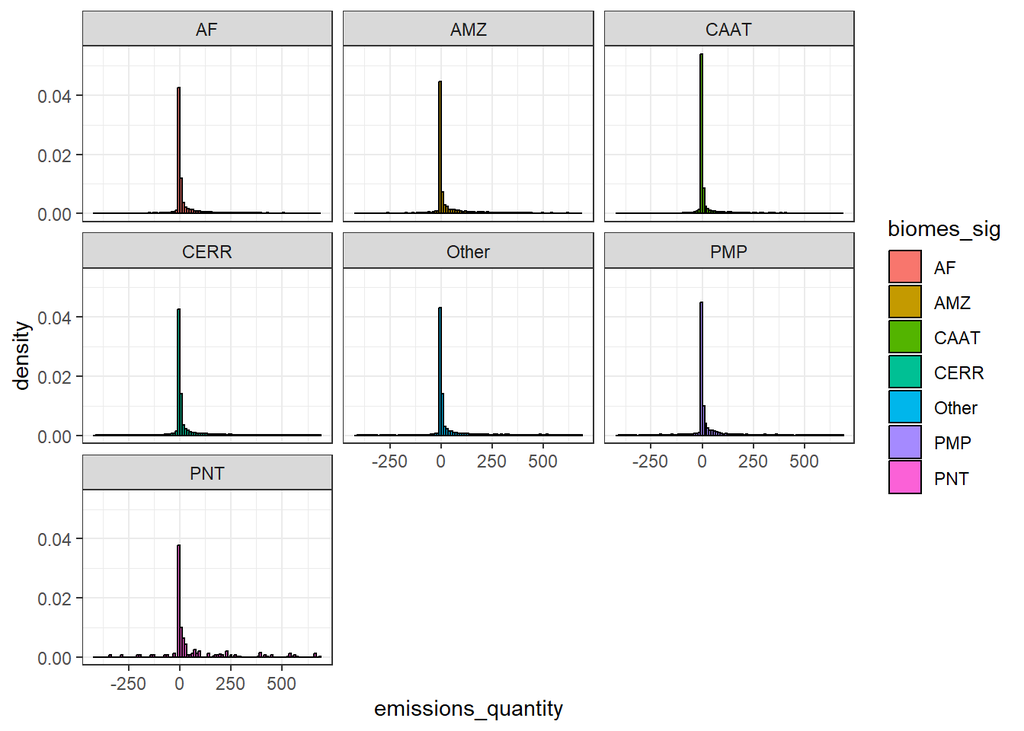

```r
x <- emissions_sources_forestry |> dplyr::pull(emissions_quantity)
x <- na.omit(x)
q1 <- quantile(x,.25)
q3 <- quantile(x,.75)
iiq <- q3-q1
emissions_sources_forestry |>
  dplyr::filter(emissions_quantity > q1-1.5*iiq, emissions_quantity<q3+1.5*iiq) |>
  ggplot2::ggplot(ggplot2::aes(x =emissions_quantity, y=..density.., fill=biomes_sig)) +
  ggplot2::geom_histogram(boundary=0, color="black",
                          bins = 100) +
  ggplot2::facet_wrap(~biomes_sig)+
  ggplot2::theme_bw()
```

### activity

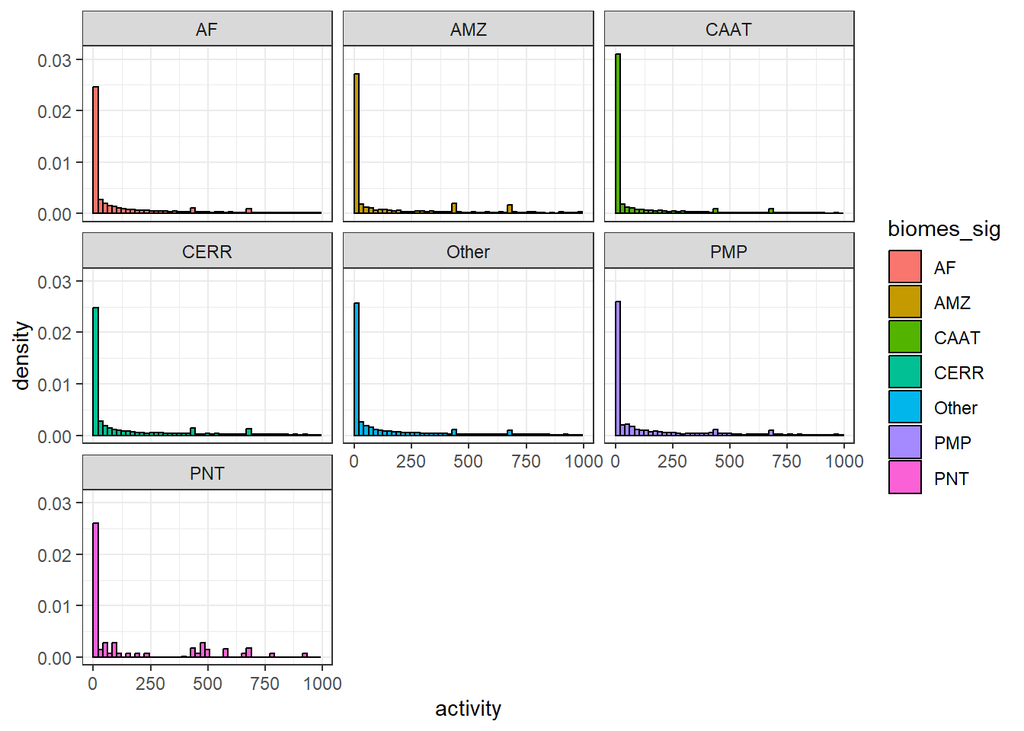

```r
x <- emissions_sources_forestry |> dplyr::pull(activity)
x <- na.omit(x)
q1 <- quantile(x,.25)
q3 <- quantile(x,.75)
iiq <- q3-q1
emissions_sources_forestry |>
  dplyr::filter(activity > q1-0.5*iiq, activity<q3*.01) |>
  ggplot2::ggplot(ggplot2::aes(x =activity, y=..density.., fill=biomes_sig)) +
  ggplot2::geom_histogram(boundary=0, color="black",
                          bins = 50) +
  ggplot2::facet_wrap(~biomes_sig)+
  ggplot2::theme_bw()
```

### emissions_factor

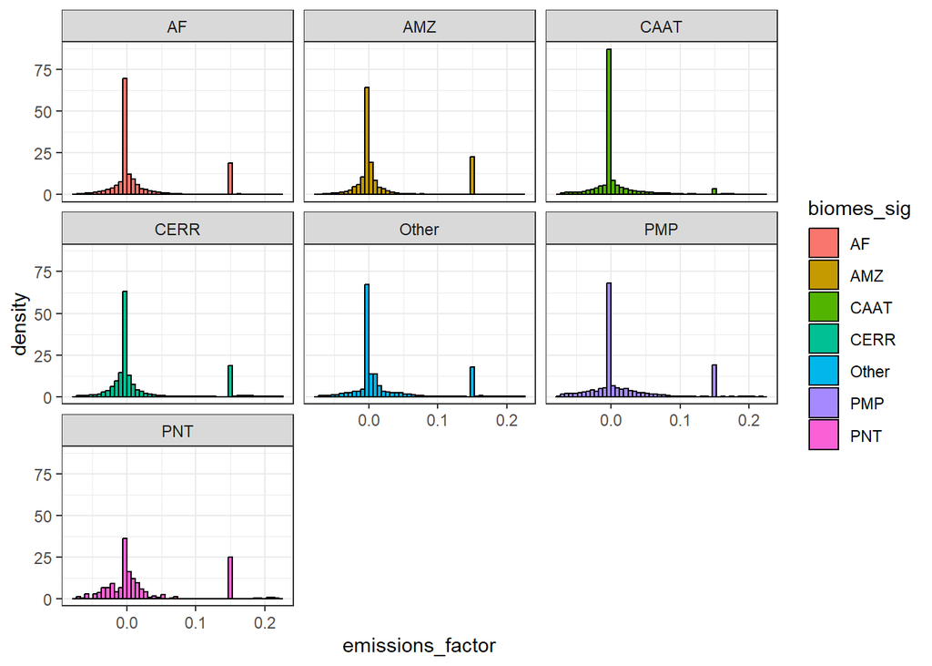

```r
x <- emissions_sources_forestry |> dplyr::pull(emissions_factor)
x <- na.omit(x)
q1 <- quantile(x,.25)
q3 <- quantile(x,.75)
iiq <- q3-q1
emissions_sources_forestry |>
  dplyr::filter(emissions_factor > q1-0.5*iiq, emissions_factor<q3+0.5*iiq) |>
  ggplot2::ggplot(ggplot2::aes(x =emissions_factor, y = ..density.. ,fill=biomes_sig)) +
  ggplot2::geom_histogram(boundary=0, color="black",
                          bins = 50) +
  ggplot2::facet_wrap(~biomes_sig)+
  ggplot2::theme_bw()
```

### capacity

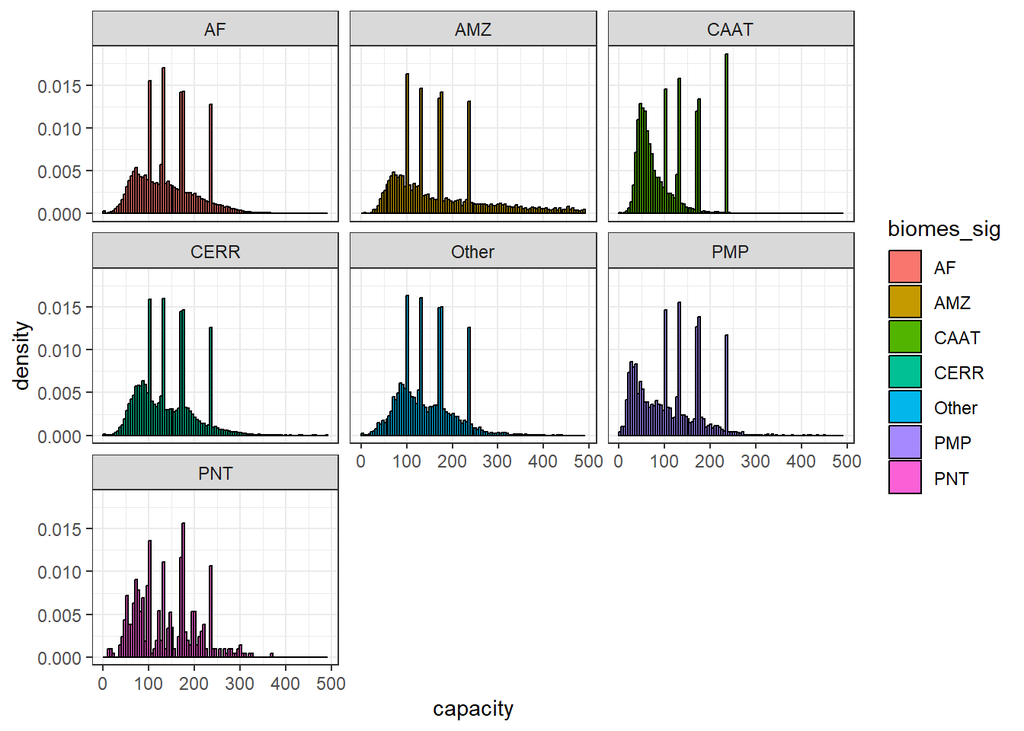

```r
x <- emissions_sources_forestry |> dplyr::pull(capacity)
x <- na.omit(x)
q1 <- quantile(x,.25)
q3 <- quantile(x,.75)
iiq <- q3-q1
emissions_sources_forestry |>
  dplyr::filter(capacity > q1-3.5*iiq, capacity<q3+3.5*iiq) |>
  ggplot2::ggplot(ggplot2::aes(x =capacity, y=..density.., fill=biomes_sig)) +
  ggplot2::geom_histogram(boundary=0, color="black",
                          bins = 100) +
  ggplot2::facet_wrap(~biomes_sig)+
  ggplot2::theme_bw()
```

### capacity_factor

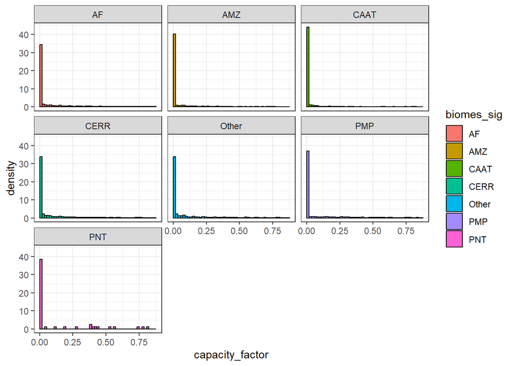

```r
x <- emissions_sources_forestry |> dplyr::pull(capacity_factor)
x <- na.omit(x)
q1 <- quantile(x,.25)
q3 <- quantile(x,.75)
iiq <- q3-q1
emissions_sources_forestry |>
  dplyr::filter(capacity_factor > q1-0.5*iiq, capacity_factor<q3*.001) |>
  ggplot2::ggplot(ggplot2::aes(x =capacity_factor, y=..density..,fill=biomes_sig)) +
  ggplot2::geom_histogram(boundary=0, color="black",
                          bins = 50) +
  ggplot2::facet_wrap(~biomes_sig)+
  ggplot2::theme_bw()
```